# Transformations

Centring, standardising, correlation and logarithms

Dr Massimiliano Canzi

# Transforming variables

`Did you know:` the blue whale is the largest animal known to have lived. The biggest accurately measured one, a female, was 29.5 m long and weighed 180 tonnes.

*Sources: Encyclopaedia Britannica; WWF*

## Today

- Why we transform variables
- Linear transformations: units, centring, standardising
- Correlation: Pearson’s r, and what it hides
- Logarithms: for predictors and for outcomes
- A note on the word “normalising”

## Data from {simling}

From today, most examples use data sets from `{simling}`, which you met in tutorial 1. The data are simulated, so we know the true effects.

```r
library(simling)
?megastudy
```

`megastudy`: item norms for 6000 words, as in large lexical decision megastudies. One row per word, with its mean reaction time (`rt`, in ms) and its age of acquisition (`aoa`, in years).

## Age of acquisition and reaction time

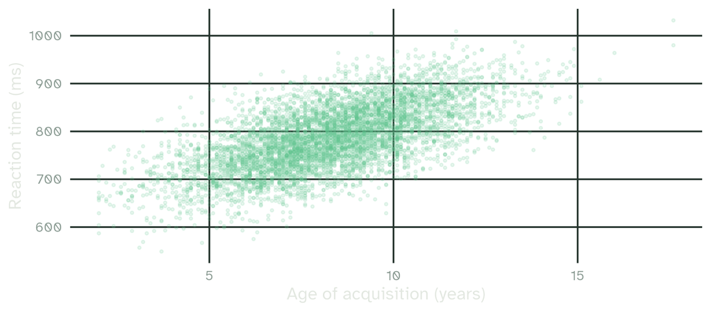

Each point is one of the 6000 words. Words learned later tend to take longer to recognise, and the cloud of points is roughly straight, so a linear model is a reasonable start.

## A simple regression

```r
words <- megastudy
m <- lm(rt ~ aoa, data = words)
tidy(m)[, 1:3]
```

```
# A tibble: 2 × 3
  term        estimate std.error
  <chr>          <dbl>     <dbl>
1 (Intercept)    623.      2.64
2 aoa             19.9     0.308
```

Each extra year of age of acquisition goes with responses 19.9 ms slower, and a word learned at age 0 would take 623 ms.

The model is fine, but its intercept describes a word learned at birth, far outside the data. Today we fix that, and change the scale of the slope, without touching the fit.

## Why transform?

| Goal | Example | Transformation |
| --- | --- | --- |
| Coefficients that are easier to read | slope per month, intercept for a word of average age of acquisition | units, centring |
| Predictors on a common scale | age of acquisition (years) against word length (letters) | standardising |
| A shape the linear model can handle | skewed reaction times, word frequencies | logarithm |

Changing units, centring and standardising relabel the axis and leave the shape of the data as it is. The logarithm changes the shape as well.

## Linear vs non-linear

A linear transformation shifts every value by the same amount, rescales every value by the same factor, or both. A non-linear one, such as the logarithm, changes the shape of the distribution.

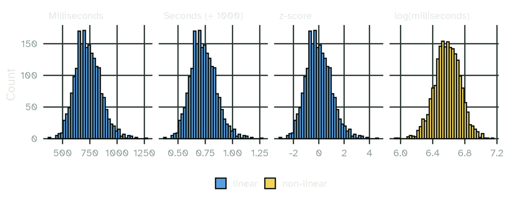

Reaction times from `zipf_rt` on four scales. The three linear ones are the same histogram with different numbers on the axis. Only the log changes the shape.

# Linear transformations

`Did you know:` a nursing blue whale calf gains up to 90 kg a day: that is 3.75 kg an hour, or 0.09 tonnes a day. The three numbers describe the same growth in different units.

*Source: Encyclopaedia Britannica*

## Changing units

```r
words <- words |> mutate(aoa_months = aoa * 12)

coef(lm(rt ~ aoa, data = words))
```

```
(Intercept)         aoa
  622.65894    19.89087
```

```r
coef(lm(rt ~ aoa_months, data = words))
```

```
(Intercept)  aoa_months
 622.658938    1.657573
```

Multiply the predictor by 12, and the slope is divided by 12: 1.66 ms per month.

The line and its R² (0.41) stay the same; the numbers are just easier to read.

## Where is the intercept?

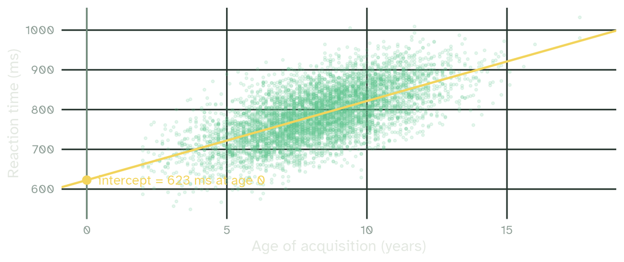

The intercept is where the line crosses x = 0: far outside the data.

## Centring

Centring subtracts the mean, so that 0 means “a word of average age of acquisition”:

```r
words <- words |>
  mutate(aoa_c = aoa - mean(aoa))

coef(lm(rt ~ aoa_c, data = words))
```

```
(Intercept)       aoa_c
  787.51050    19.89087
```

```r
mean(words$rt)
```

```
[1] 787.5105
```

The slope does not change. The intercept is now the mean reaction time: the predicted value for a word of average age of acquisition.

## Centring

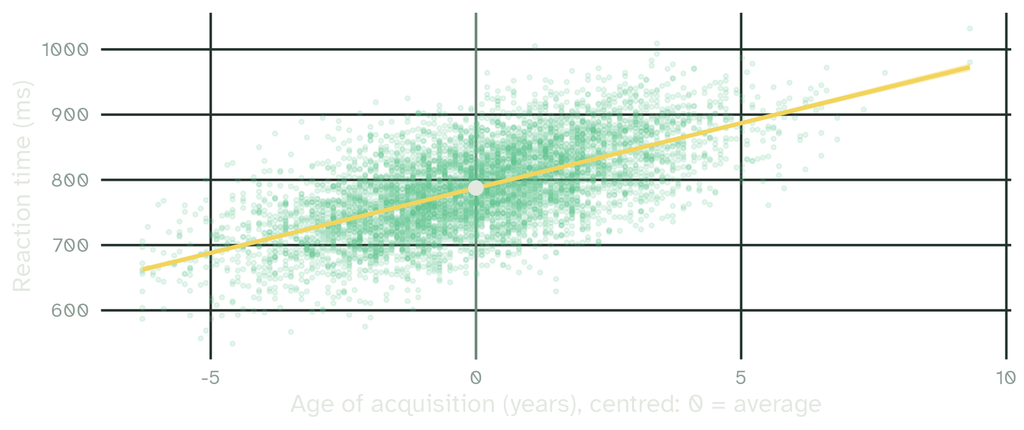

The data and the line are unchanged, and only the `x` axis has moved. The intercept (white) sits in the middle of the data.

## Centre on any meaningful value

The mean is not the only choice. Subtract any value that makes 0 meaningful:

```r
words <- words |> mutate(aoa_6 = aoa - 6)
coef(lm(rt ~ aoa_6, data = words))
```

```
(Intercept)       aoa_6
  742.00416    19.89087
```

The intercept is now the predicted reaction time for a word learned at age 6, when most children start school.

In linguistic data:

| Centred predictor | The intercept describes |
| --- | --- |
| `age - 18` | an 18-year-old speaker |
| `year - 2000` | the year 2000 |
| `trial - 1` | the first trial |

## Standardising

Standardising turns values into z-scores: subtract the mean, then divide by the standard deviation.

z = (x − mean) / SD

```r
words <- words |>
  mutate(aoa_z = (aoa - mean(aoa)) / sd(aoa))

coef(lm(rt ~ aoa_z, data = words))
```

```
(Intercept)       aoa_z
  787.51050    43.31431
```

The slope is now the change in reaction time for a word acquired one standard deviation later.

## What a z-score says

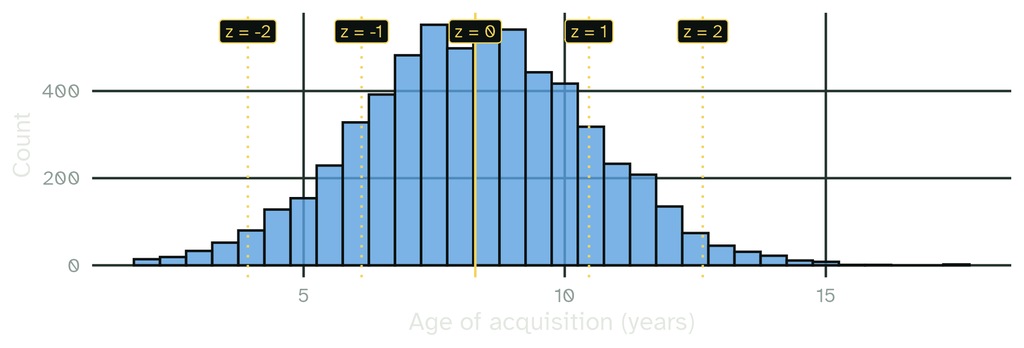

A z-score says how many standard deviations a value lies from the mean: z = 0 is average, z = −2 is two SDs below it. From lecture 3, about 95% of values in a normal distribution lie between z = −2 and z = 2.

## Comparing predictors

Which predicts reaction time more strongly: age of acquisition (years) or word length (letters)?

```r
c(coef(lm(rt ~ aoa, data = words))[2],
  coef(lm(rt ~ length, data = words))[2])
```

```
     aoa   length
19.89087 20.61009
```

Years and letters cannot be compared. Standardise both. `scale()` computes z-scores, but returns a matrix, so wrap it in `as.numeric()`:

```r
words <- words |> mutate(length_z = as.numeric(scale(length)))
c(coef(lm(rt ~ aoa_z, data = words))[2],
  coef(lm(rt ~ length_z, data = words))[2])
```

```
   aoa_z length_z
43.31431 41.37896
```

In raw units, length looked slightly stronger. Per standard deviation, age of acquisition goes with the larger change in reaction time.

## Speaker normalisation

Vowel formants are a classic linguistic use of z-scores, in speaker normalisation.

Speakers with longer vocal tracts have lower formants overall. Raw F1 and F2 mix up which vowel and which speaker.

```r
formants
```

```
# A tibble: 120 × 5
  speaker vowel token    f1    f2
  <fct>   <fct> <int> <dbl> <dbl>
1 A       a         1   747  1163
2 A       a         2   784  1093
3 A       a         3   731  1256
4 A       a         4   728  1519
# ℹ 116 more rows
```

`formants`: 20 tokens of /i a u/ from each of two speakers. Every formant of speaker B is 1.2 times the same formant of speaker A.

## Raw formants

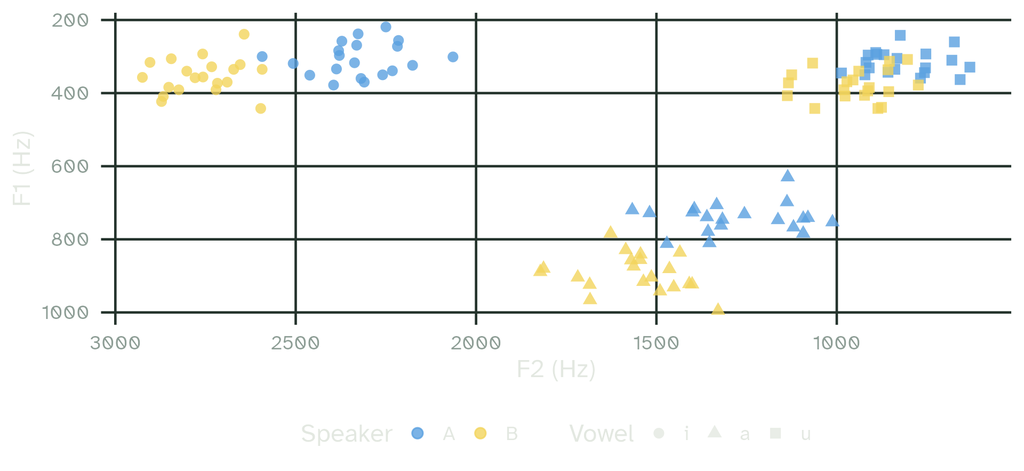

The same vowels from two speakers land in different places.

## Lobanov normalisation

z-score each formant within each speaker (Lobanov, 1971). With `.by` from lecture 2:

```r
formants_z <- formants |>
  mutate(across(c(f1, f2), \(x) as.numeric(scale(x))),
         .by = speaker)
```

`.by = speaker`: each speaker’s F1 and F2 are z-scored using that speaker’s own mean and SD.

## After normalisation

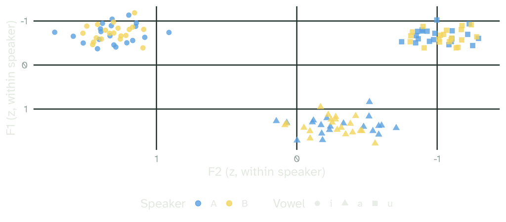

After normalisation, the vowels overlap across speakers.

## Discussion

Lobanov normalisation removes the differences between speakers, so that vowels can be compared across them.

- When could those differences be exactly what you want to study?
- What would you lose by normalising in that case?

## Linear transformations: summary

| predictor | 0 means | intercept | slope | slope per | R2 |
| --- | --- | --- | --- | --- | --- |
| aoa | age 0 | 622.659 | 19.891 | 1 year | 0.41 |
| aoa_months | age 0 | 622.659 | 1.658 | 1 month | 0.41 |
| aoa_c | average age of acquisition | 787.510 | 19.891 | 1 year | 0.41 |
| aoa_6 | age 6 | 742.004 | 19.891 | 1 year | 0.41 |
| aoa_z | average age of acquisition | 787.510 | 43.314 | 1 SD | 0.41 |

Linear transformations change what the numbers mean, while the fit stays the same.

# Correlation

`Did you know:` the heart of a blue whale that washed ashore in Newfoundland, Canada, in 2014 weighed about 180 kg. It is now on display at the Royal Ontario Museum in Toronto.

*Source: Royal Ontario Museum*

## Pearson’s r

The correlation coefficient r measures how closely two variables follow a straight line.

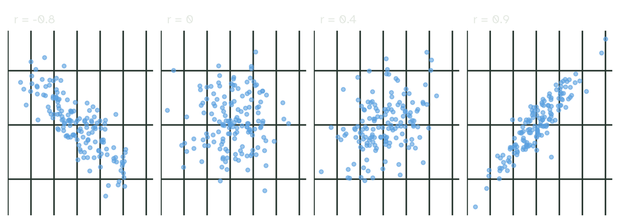

- From -1 (perfect negative) through 0 (no linear relation) to +1 (perfect positive)
- It has no units: it is the same whether you measure in years, months or days

## Computing correlations with `cor()`

```r
cor(words$rt, words$aoa)
```

```
[1] 0.6405983
```

`language_attitudes`: 320 respondents rate dialect speakers on 1 to 5 scales. Some respondents skipped items, so those cells are `NA`:

```r
cor(language_attitudes$friendly, language_attitudes$warm)
```

```
[1] NA
```

As with `mean()` in lecture 2, one `NA` makes the whole result `NA`. In `cor()`, the argument is `use = "complete.obs"`, which keeps only the respondents who answered both items:

```r
cor(language_attitudes$friendly, language_attitudes$warm, use = "complete.obs")
```

```
[1] 0.5708202
```

## Correlations per group

Per group, with `summarise()` and `.by`:

```r
language_attitudes |>
  summarise(r = cor(friendly, warm, use = "complete.obs"), .by = dialect_speaker)
```

```
# A tibble: 2 × 2
  dialect_speaker     r
  <fct>           <dbl>
1 yes             0.641
2 no              0.515
```

## Correlation and regression

Standardise both variables, and the regression slope is the correlation:

```r
words <- words |> mutate(rt_z = as.numeric(scale(rt)))

coef(lm(rt_z ~ aoa_z, data = words))
```

```
 (Intercept)        aoa_z
5.096536e-16 6.405983e-01
```

```r
cor(words$rt, words$aoa)
```

```
[1] 0.6405983
```

And in simple regression, R² = r²:

```r
cor(words$rt, words$aoa)^2
```

```
[1] 0.4103661
```

```r
glance(m)$r.squared
```

```
[1] 0.4103661
```

## Anscombe’s quartet

Anscombe (1973) built four data sets, available in R as `anscombe`:

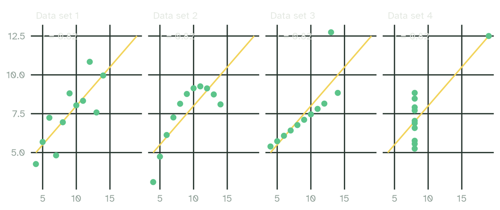

Four data sets with the same means, the same regression line and the same correlation, r = 0.82. Only one of them looks like a straight-line relationship, which is why you should plot the data before you trust r.

## Correlation by group

F1 and F2 in the formant data:

```r
cor(formants$f1, formants$f2)
```

```
[1] -0.1784547
```

```r
formants |> summarise(r = cor(f1, f2), .by = vowel)
```

```
# A tibble: 3 × 2
  vowel     r
  <fct> <dbl>
1 a     0.580
2 i     0.472
3 u     0.394
```

Negative overall, positive within every vowel: Simpson’s paradox, as with last week’s penguins. Across vowels, a high F1 goes with a low F2 (/a/ against /i/). Within a vowel, speaker B has both formants higher. A correlation describes only the data you give it, and says nothing about the process behind them.

## Correlation and causation

In children, shoe size and vocabulary size are correlated: children with bigger feet tend to know more words.

Foot size has no effect on vocabulary. Both grow with a third variable, age.

A correlation, or a regression slope, tells us that two variables go together. Whether one causes the other is a question for the design of the study.

## Discussion

Suppose children who are read to at home every day know more words than children who are not.

- Does reading aloud cause vocabulary growth? What else could explain the correlation?
- What kind of study would let you decide?

# Logarithms

`Did you know:` blue whale calls can reach 188 decibels. Decibels are a logarithmic scale: every 10 dB more means ten times the sound intensity.

*Source: WWF*

## Orders of magnitude

Some linguistic variables span many orders of magnitude. Word frequency is the classic example:

```r
zipf_rt
```

```
# A tibble: 2,000 × 4
  word   rank  freq    rt
  <fct> <int> <dbl> <dbl>
1 w0001    49 1020.   511
2 w0002    70  714.   738
3 w0003   125  400    624
4 w0004   135  370.   522
# ℹ 1,996 more rows
```

```r
range(zipf_rt$freq)
```

```
[1]    1.00 1020.41
```

`zipf_rt`: 2000 words with their frequency per million words and a lexical decision time (`rt`, in ms). The most frequent word is about 1020 times more frequent than the least frequent one.

## What is a logarithm?

A logarithm answers one question: how many times do I multiply the base by itself to get this number? `log10(1000)` is 3, because 10 × 10 × 10 = 1000.

So the log turns multiplying into adding: each step of 1 on the log scale is one more multiplication by the base.

```r
log10(1000)
```

```
[1] 3
```

```r
log2(8)
```

```
[1] 3
```

```r
log(exp(2))
```

```
[1] 2
```

```r
exp(log(50))
```

```
[1] 50
```

`log()` is the natural log, with base e ≈ 2.718, and `exp()` undoes it.

## Which base?

| Function | Base | One unit means |
| --- | --- | --- |
| `log10()` | 10 | a tenfold increase |
| `log2()` | 2 | a doubling |
| `log()` | e ≈ 2.718 | the default in R and in most models |

The base changes only the numbers on the axis, and the shape stays the same: `log10(x)` is just `log(x) / log(10)`. Choose the base that is easiest to explain.

## Zeros and negatives

```r
log(0)
```

```
[1] -Inf
```

```r
log(-5)
```

```
[1] NaN
```

The log is only defined for positive numbers.

Frequency counts often contain zeros (a word that never occurs in a corpus). A common fix is to add 1 first. `log1p(x)` is the same as `log(x + 1)`:

```r
log1p(c(0, 9, 99))
```

```
[1] 0.000000 2.302585 4.605170
```

## Logging a predictor

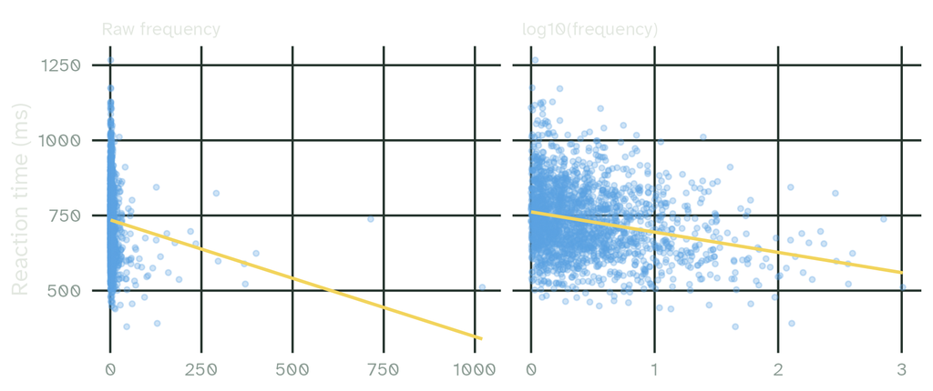

On the raw scale, most words are squeezed against zero and a straight line fits badly. On the log scale, the relationship is close to linear.

## Logging a predictor

```r
m_freq <- lm(rt ~ log10(freq), data = zipf_rt)
coef(m_freq)
```

```
(Intercept) log10(freq)
  761.88925   -67.32764
```

Each tenfold increase in frequency (10 → 100 → 1000) goes with responses about 67 ms faster.

Frequency effects in language are usually multiplicative: going from 10 to 100 matters about as much as going from 100,000 to 1,000,000.

## Logging the outcome

Reaction times are positive and right-skewed (lecture 3). So are the residuals of a model fitted to raw RTs:

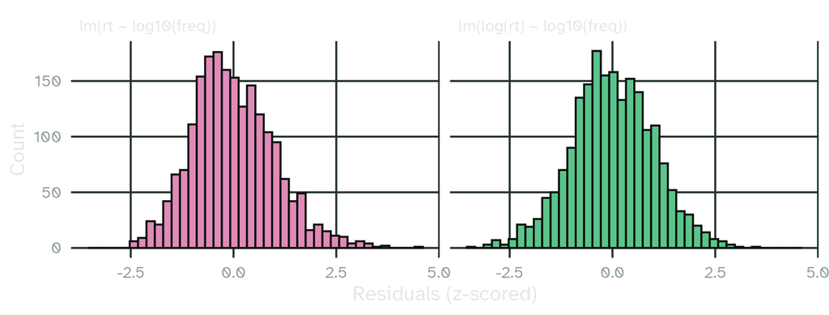

After the log, the residuals are much more symmetric: closer to what the linear model assumes (lecture 4).

## Reading a log outcome

```r
m_log <- lm(log(rt) ~ log10(freq), data = zipf_rt)
coef(m_log)
```

```
(Intercept) log10(freq)
 6.62591038 -0.09607583
```

```r
exp(coef(m_log)[2])
```

```
log10(freq)
  0.9083951
```

On the log scale, effects multiply. Each tenfold increase in frequency multiplies the RT by 0.908: responses about 9.2% faster.

Back to milliseconds with `exp()`:

```r
exp(predict(m_log, newdata = tibble(freq = c(1, 10, 100, 1000))))
```

```
       1        2        3        4
754.3907 685.2848 622.5094 565.4845
```

## When to log

- The variable is positive and right-skewed: RTs, durations, frequencies, counts
- Effects are plausibly multiplicative: “x% faster” rather than “x ms faster”
- The residuals of the raw model are skewed or funnel-shaped

A log transformation does not fix every problem. Report which variables you transformed and why, and interpret the coefficients on the transformed scale.

# The word “normalising”

## Kinds of normalising

“Normalising” is used for several different operations:

| What people mean | What it does |
| --- | --- |
| z-scoring | subtracts the mean and divides by the SD |
| min-max scaling | squeezes values into the range 0 to 1 |
| a normalising transformation | makes a distribution look more normal, e.g. a log |
| speaker normalisation | removes vocal tract differences in phonetics, e.g. Lobanov |

Min-max scaling in R:

```r
x <- c(4, 8, 15, 16, 23, 42)
(x - min(x)) / (max(x) - min(x))
```

```
[1] 0.0000000 0.1052632 0.2894737 0.3157895 0.5000000 1.0000000
```

In your write-up, avoid the word on its own. Say exactly what you did: “F1 and F2 were z-scored within speaker (Lobanov, 1971)”. See also Winter (2019), section 5.7.

## Summary

- Changing units and centring change what the intercept and slope mean, and the fit stays the same
- Standardising puts variables on a common scale, with slopes per SD
- Correlation is the slope between two z-scored variables: unitless, from −1 to 1
- The same r can come from very different data, so plot the data too
- Logarithms turn multiplicative effects into additive ones, and reduce skew
- Name your transformation precisely, instead of just writing “normalised”

## Reading

This lecture follows chapter 5 of Winter (2019).

Winter, B. (2019). *Statistics for linguists: An introduction using R*. Routledge. https://doi.org/10.4324/9781315165547

## Slides and code

[figure not shown]

These slides

mcanzi.de/statistics/05_transformations.html

Code, data and all lectures

github.com/mcanzi/statistics